# Ford GoBike Data Analysis

## Preliminary Wrangling

Bay wheels was primarily a public bicycle sharing system in California which started working in 2013 as "Bay Area Bike Share". After 5 years in 2018 it had over 2,600 bicycles in 262 stations around San Fransisco, East Bay and San Jose. From 2017, Ford Motor company took partnership and company been renamed to Ford GoBike. After Motivate's acquisition by [Lyft](https://en.wikipedia.org/wiki/Bay_Wheels), the system was renamed to Bay Wheels in June 2021.

Bay Wheels fleets has two types of bicycles, 1. classic docked model and 2. hybrid model wich can be parked either at a dock or even without that. Both types of bicycles had contactless smart card reader. they are available 24/7 which can be hired by customer in different way( single hire, annual membership etc) single rides start at \$3 per ride and can be up to 159 for annual membership.

```python
# import all packages and set plots to be embedded inline
import numpy as np
import pandas as pd
import matplotlib.pyplot as plt
import seaborn as sb
import os
import glob

%matplotlib inline
```

### Preliminary Wrangling

```python
data_folder = 'Data'
frames = [pd.read_csv(f) for f in glob.glob(os.path.join(data_folder, '*.csv'))]
results = pd.concat(frames, ignore_index=True)
```

```python
results.shape
```

```
(1863721, 16)
```

```python
results.head()
```

|  | duration_sec | start_time | end_time | start_station_id | start_station_name | start_station_latitude | start_station_longitude | end_station_id | end_station_name | end_station_latitude | end_station_longitude | bike_id | user_type | member_birth_year | member_gender | bike_share_for_all_trip |
| --- | --- | --- | --- | --- | --- | --- | --- | --- | --- | --- | --- | --- | --- | --- | --- | --- |
| 0 | 75284 | 2018-01-31 22:52:35.2390 | 2018-02-01 19:47:19.8240 | 120.0 | Mission Dolores Park | 37.761420 | -122.426435 | 285.0 | Webster St at O'Farrell St | 37.783521 | -122.431158 | 2765 | Subscriber | 1986.0 | Male | No |
| 1 | 85422 | 2018-01-31 16:13:34.3510 | 2018-02-01 15:57:17.3100 | 15.0 | San Francisco Ferry Building (Harry Bridges Pl... | 37.795392 | -122.394203 | 15.0 | San Francisco Ferry Building (Harry Bridges Pl... | 37.795392 | -122.394203 | 2815 | Customer | NaN | NaN | No |
| 2 | 71576 | 2018-01-31 14:23:55.8890 | 2018-02-01 10:16:52.1160 | 304.0 | Jackson St at 5th St | 37.348759 | -121.894798 | 296.0 | 5th St at Virginia St | 37.325998 | -121.877120 | 3039 | Customer | 1996.0 | Male | No |
| 3 | 61076 | 2018-01-31 14:53:23.5620 | 2018-02-01 07:51:20.5000 | 75.0 | Market St at Franklin St | 37.773793 | -122.421239 | 47.0 | 4th St at Harrison St | 37.780955 | -122.399749 | 321 | Customer | NaN | NaN | No |
| 4 | 39966 | 2018-01-31 19:52:24.6670 | 2018-02-01 06:58:31.0530 | 74.0 | Laguna St at Hayes St | 37.776435 | -122.426244 | 19.0 | Post St at Kearny St | 37.788975 | -122.403452 | 617 | Subscriber | 1991.0 | Male | No |

```python
# save results into csv format

results.to_csv('fordgobike_trips.csv', index=False)
```

```python
#read the csv file with panda
df = pd.read_csv('fordgobike_trips.csv')
df.head()
```

|  | duration_sec | start_time | end_time | start_station_id | start_station_name | start_station_latitude | start_station_longitude | end_station_id | end_station_name | end_station_latitude | end_station_longitude | bike_id | user_type | member_birth_year | member_gender | bike_share_for_all_trip |
| --- | --- | --- | --- | --- | --- | --- | --- | --- | --- | --- | --- | --- | --- | --- | --- | --- |
| 0 | 75284 | 2018-01-31 22:52:35.2390 | 2018-02-01 19:47:19.8240 | 120.0 | Mission Dolores Park | 37.761420 | -122.426435 | 285.0 | Webster St at O'Farrell St | 37.783521 | -122.431158 | 2765 | Subscriber | 1986.0 | Male | No |
| 1 | 85422 | 2018-01-31 16:13:34.3510 | 2018-02-01 15:57:17.3100 | 15.0 | San Francisco Ferry Building (Harry Bridges Pl... | 37.795392 | -122.394203 | 15.0 | San Francisco Ferry Building (Harry Bridges Pl... | 37.795392 | -122.394203 | 2815 | Customer | NaN | NaN | No |
| 2 | 71576 | 2018-01-31 14:23:55.8890 | 2018-02-01 10:16:52.1160 | 304.0 | Jackson St at 5th St | 37.348759 | -121.894798 | 296.0 | 5th St at Virginia St | 37.325998 | -121.877120 | 3039 | Customer | 1996.0 | Male | No |
| 3 | 61076 | 2018-01-31 14:53:23.5620 | 2018-02-01 07:51:20.5000 | 75.0 | Market St at Franklin St | 37.773793 | -122.421239 | 47.0 | 4th St at Harrison St | 37.780955 | -122.399749 | 321 | Customer | NaN | NaN | No |
| 4 | 39966 | 2018-01-31 19:52:24.6670 | 2018-02-01 06:58:31.0530 | 74.0 | Laguna St at Hayes St | 37.776435 | -122.426244 | 19.0 | Post St at Kearny St | 37.788975 | -122.403452 | 617 | Subscriber | 1991.0 | Male | No |

```python
df.info()
```

```
<class 'pandas.core.frame.DataFrame'>
RangeIndex: 1863721 entries, 0 to 1863720
Data columns (total 16 columns):
 #   Column                   Dtype
---  ------                   -----
 0   duration_sec             int64
 1   start_time               object
 2   end_time                 object
 3   start_station_id         float64
 4   start_station_name       object
 5   start_station_latitude   float64
 6   start_station_longitude  float64
 7   end_station_id           float64
 8   end_station_name         object
 9   end_station_latitude     float64
 10  end_station_longitude    float64
 11  bike_id                  int64
 12  user_type                object
 13  member_birth_year        float64
 14  member_gender            object
 15  bike_share_for_all_trip  object
dtypes: float64(7), int64(2), object(7)
memory usage: 227.5+ MB
```

```python
#find the missing values in the data set
df.isnull().sum()
```

```
duration_sec                    0
start_time                      0
end_time                        0
start_station_id            11771
start_station_name          11771
start_station_latitude          0
start_station_longitude         0
end_station_id              11771
end_station_name            11771
end_station_latitude            0
end_station_longitude           0
bike_id                         0
user_type                       0
member_birth_year          110718
member_gender              110367
bike_share_for_all_trip         0
dtype: int64
```

```python
#find the duplicated data
df.duplicated().sum()
```

```
0
```

```python
df['member_gender'].value_counts()
```

```
Male      1288085
Female     438188
Other       27081
Name: member_gender, dtype: int64
```

```python
# Remove rows that does not have gender value
df_new = df[df['member_gender'].isnull() == False]
df_new.info()
```

```
<class 'pandas.core.frame.DataFrame'>
Int64Index: 1753354 entries, 0 to 1863719
Data columns (total 16 columns):
 #   Column                   Dtype
---  ------                   -----
 0   duration_sec             int64
 1   start_time               object
 2   end_time                 object
 3   start_station_id         float64
 4   start_station_name       object
 5   start_station_latitude   float64
 6   start_station_longitude  float64
 7   end_station_id           float64
 8   end_station_name         object
 9   end_station_latitude     float64
 10  end_station_longitude    float64
 11  bike_id                  int64
 12  user_type                object
 13  member_birth_year        float64
 14  member_gender            object
 15  bike_share_for_all_trip  object
dtypes: float64(7), int64(2), object(7)
memory usage: 227.4+ MB
```

```python
df_new['start_time']
```

```
0          2018-01-31 22:52:35.2390
2          2018-01-31 14:23:55.8890
4          2018-01-31 19:52:24.6670
6          2018-01-31 23:53:53.6320
7          2018-01-31 23:52:09.9030
                     ...
1863715    2018-12-01 00:01:49.6930
1863716    2018-12-01 00:11:54.8110
1863717    2018-12-01 00:02:48.7260
1863718    2018-12-01 00:05:27.6150
1863719    2018-12-01 00:03:06.5490
Name: start_time, Length: 1753354, dtype: object
```

```python
df_new['member_gender'].value_counts()
```

```
Male      1288085
Female     438188
Other       27081
Name: member_gender, dtype: int64
```

```python
# Remove reows that does not have station id
df_new = df_new[df_new['start_station_id'].isnull() == False]
df_new.info()
```

```
<class 'pandas.core.frame.DataFrame'>
Int64Index: 1741907 entries, 0 to 1863719
Data columns (total 16 columns):
 #   Column                   Dtype
---  ------                   -----
 0   duration_sec             int64
 1   start_time               object
 2   end_time                 object
 3   start_station_id         float64
 4   start_station_name       object
 5   start_station_latitude   float64
 6   start_station_longitude  float64
 7   end_station_id           float64
 8   end_station_name         object
 9   end_station_latitude     float64
 10  end_station_longitude    float64
 11  bike_id                  int64
 12  user_type                object
 13  member_birth_year        float64
 14  member_gender            object
 15  bike_share_for_all_trip  object
dtypes: float64(7), int64(2), object(7)
memory usage: 225.9+ MB
```

```python
# Change start_time and end_time to datetime format
df_new.start_time = pd.to_datetime(df_new.start_time)
df_new.end_time = pd.to_datetime(df_new.end_time)

df_new['start_station_id'] = df_new['start_station_id'].astype('str')
df_new['end_station_id'] = df_new['end_station_id'].astype('str')
df_new['bike_id'] = df_new['bike_id'].astype('str')
```

```python
#  "day" of week and "hours" information from the start_time column
df_new['start_time_day']= df_new['start_time'].dt.strftime('%a')
df_new['start_time_hour']= df_new['start_time'].dt.hour
df_new['start_month'] = df_new['start_time'].dt.strftime('%B')
```

```python
df_new['start_time_day'].value_counts()
df_new['start_month'].value_counts()
```

```
October      191499
July         183733
June         181443
August       178415
September    174803
May          167413
November     128564
December     126162
April        121827
March        102385
February      98662
January       87001
Name: start_month, dtype: int64
```

```python
weekdays = ['Mon','Tue','Wed','Thu','Fri', 'Sat', 'Sun']
weekdays_list = pd.api.types.CategoricalDtype(ordered = True, categories = weekdays)
df_new['start_time_day'] = df_new['start_time_day'].astype(weekdays_list)
```

```python
df_new['start_time_day']
```

```
0          Wed
2          Wed
4          Wed
6          Wed
7          Wed
          ...
1863715    Sat
1863716    Sat
1863717    Sat
1863718    Sat
1863719    Sat
Name: start_time_day, Length: 1741907, dtype: category
Categories (7, object): ['Mon' < 'Tue' < 'Wed' < 'Thu' < 'Fri' < 'Sat' < 'Sun']
```

```python
# Calculate member_age from member_birth_year.
df_new['members_age'] = 2021 - df_new['member_birth_year']
```

```python
df_new = df_new[df_new['members_age'].isnull() == False]
```

```python
df_new['members_age'] = df_new['members_age'].astype('int')
df_new['member_birth_year'] = df_new['member_birth_year'].astype('int')
```

```python
df_new['members_age']
```

```
0          35
2          25
4          30
6          33
7          41
           ..
1863715    31
1863716    39
1863717    22
1863718    30
1863719    58
Name: members_age, Length: 1741556, dtype: int32
```

```python
#maximum age is 140 years old!
df_new['members_age'].describe()
```

```
count    1.741556e+06
mean     3.793921e+01
std      1.045133e+01
min      2.100000e+01
25%      3.000000e+01
50%      3.600000e+01
75%      4.300000e+01
max      1.400000e+02
Name: members_age, dtype: float64
```

## What is the structure of your dataset?¶

- trip duration: how long the trip took in seconds
- start and end time, start, end date, time for the bikers.
- stations: start,end station, name
- Customer data: gender, birth date and user type
- rented bikes: bike id

## What is/are the main feature(s) of interest in your dataset?

- trip duration

## What features in the dataset do you think will help support your investigation into your feature(s) of interest?

- members age
- start time
- gender
- user type
- special pattern associated with a specific group of riders

## Univariate Exploration

```python
# add new columns for trip duration in minute,
df_new['duration_min'] = df_new['duration_sec']/60

df_new.head()
```

|  | duration_sec | start_time | end_time | start_station_id | start_station_name | start_station_latitude | start_station_longitude | end_station_id | end_station_name | end_station_latitude | ... | bike_id | user_type | member_birth_year | member_gender | bike_share_for_all_trip | start_time_day | start_time_hour | start_month | members_age | duration_min |
| --- | --- | --- | --- | --- | --- | --- | --- | --- | --- | --- | --- | --- | --- | --- | --- | --- | --- | --- | --- | --- | --- |
| 0 | 75284 | 2018-01-31 22:52:35.239 | 2018-02-01 19:47:19.824 | 120.0 | Mission Dolores Park | 37.761420 | -122.426435 | 285.0 | Webster St at O'Farrell St | 37.783521 | ... | 2765 | Subscriber | 1986 | Male | No | Wed | 22 | January | 35 | 1254.733333 |
| 2 | 71576 | 2018-01-31 14:23:55.889 | 2018-02-01 10:16:52.116 | 304.0 | Jackson St at 5th St | 37.348759 | -121.894798 | 296.0 | 5th St at Virginia St | 37.325998 | ... | 3039 | Customer | 1996 | Male | No | Wed | 14 | January | 25 | 1192.933333 |
| 4 | 39966 | 2018-01-31 19:52:24.667 | 2018-02-01 06:58:31.053 | 74.0 | Laguna St at Hayes St | 37.776435 | -122.426244 | 19.0 | Post St at Kearny St | 37.788975 | ... | 617 | Subscriber | 1991 | Male | No | Wed | 19 | January | 30 | 666.100000 |
| 6 | 453 | 2018-01-31 23:53:53.632 | 2018-02-01 00:01:26.805 | 110.0 | 17th & Folsom Street Park (17th St at Folsom St) | 37.763708 | -122.415204 | 134.0 | Valencia St at 24th St | 37.752428 | ... | 3571 | Subscriber | 1988 | Male | No | Wed | 23 | January | 33 | 7.550000 |
| 7 | 180 | 2018-01-31 23:52:09.903 | 2018-01-31 23:55:10.807 | 81.0 | Berry St at 4th St | 37.775880 | -122.393170 | 93.0 | 4th St at Mission Bay Blvd S | 37.770407 | ... | 1403 | Subscriber | 1980 | Male | No | Wed | 23 | January | 41 | 3.000000 |

5 rows × 21 columns

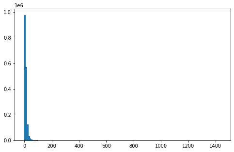

```python
binsize = 10
bins = np.arange(0, df_new['duration_min'].max()+binsize, binsize)

plt.figure(figsize=[8, 5])

plt.hist(data = df_new, x = 'duration_min', bins=bins);
```

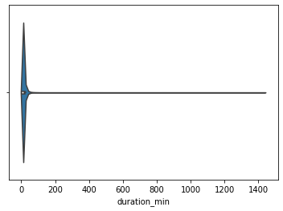

```python
sb.violinplot(data= df_new, x = 'duration_min');
```

Looks like most of the data are below 100 mins

```python
df_new['duration_min'].describe()
```

```
count    1.741556e+06
mean     1.288104e+01
std      3.238413e+01
min      1.016667e+00
25%      5.733333e+00
50%      9.050000e+00
75%      1.398333e+01
max      1.438017e+03
Name: duration_min, dtype: float64
```

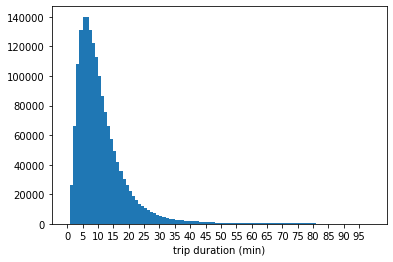

```python
bins = np.arange(0, 100, 1)
ticks = np.arange(0,100, 5)
plt.hist(data= df_new, x= 'duration_min', bins= bins)
plt.xlabel('trip duration (min)')

plt.xticks(ticks, ticks);
```

it shows almost all of the trip duration was less than 60 minutes and most of them were between 5 to 10 mins. let's remove the outlier.

```python
df_new = df_new[df_new['duration_min'] <= 60]
df_new.info()
```

```
<class 'pandas.core.frame.DataFrame'>
Int64Index: 1722559 entries, 6 to 1863719
Data columns (total 21 columns):
 #   Column                   Dtype
---  ------                   -----
 0   duration_sec             int64
 1   start_time               datetime64[ns]
 2   end_time                 datetime64[ns]
 3   start_station_id         object
 4   start_station_name       object
 5   start_station_latitude   float64
 6   start_station_longitude  float64
 7   end_station_id           object
 8   end_station_name         object
 9   end_station_latitude     float64
 10  end_station_longitude    float64
 11  bike_id                  object
 12  user_type                object
 13  member_birth_year        int32
 14  member_gender            object
 15  bike_share_for_all_trip  object
 16  start_time_day           category
 17  start_time_hour          int64
 18  start_month              object
 19  members_age              int32
 20  duration_min             float64
dtypes: category(1), datetime64[ns](2), float64(5), int32(2), int64(2), object(9)
memory usage: 264.5+ MB
```

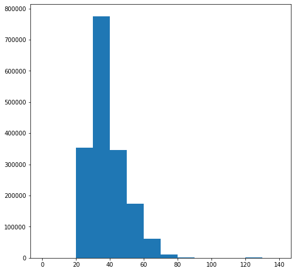

```python
# plot the distribution of members' age

plt.figure(figsize=[8, 8])
bin_size = 10
bins = np.arange(0, df_new['members_age'].max()+bin_size, bin_size)
plt.hist(df_new['members_age'], bins);
```

Remove outliers. Only keep the member_age below 70 (based on the plot).

```python
df_new = df_new[df_new.members_age < 70]
```

```python
df_new.head()
```

|  | duration_sec | start_time | end_time | start_station_id | start_station_name | start_station_latitude | start_station_longitude | end_station_id | end_station_name | end_station_latitude | ... | bike_id | user_type | member_birth_year | member_gender | bike_share_for_all_trip | start_time_day | start_time_hour | start_month | members_age | duration_min |
| --- | --- | --- | --- | --- | --- | --- | --- | --- | --- | --- | --- | --- | --- | --- | --- | --- | --- | --- | --- | --- | --- |
| 6 | 453 | 2018-01-31 23:53:53.632 | 2018-02-01 00:01:26.805 | 110.0 | 17th & Folsom Street Park (17th St at Folsom St) | 37.763708 | -122.415204 | 134.0 | Valencia St at 24th St | 37.752428 | ... | 3571 | Subscriber | 1988 | Male | No | Wed | 23 | January | 33 | 7.55 |
| 7 | 180 | 2018-01-31 23:52:09.903 | 2018-01-31 23:55:10.807 | 81.0 | Berry St at 4th St | 37.775880 | -122.393170 | 93.0 | 4th St at Mission Bay Blvd S | 37.770407 | ... | 1403 | Subscriber | 1980 | Male | No | Wed | 23 | January | 41 | 3.00 |
| 8 | 996 | 2018-01-31 23:34:56.004 | 2018-01-31 23:51:32.674 | 134.0 | Valencia St at 24th St | 37.752428 | -122.420628 | 4.0 | Cyril Magnin St at Ellis St | 37.785881 | ... | 3675 | Subscriber | 1987 | Male | Yes | Wed | 23 | January | 34 | 16.60 |
| 9 | 825 | 2018-01-31 23:34:14.027 | 2018-01-31 23:47:59.809 | 305.0 | Ryland Park | 37.342725 | -121.895617 | 317.0 | San Salvador St at 9th St | 37.333955 | ... | 1453 | Subscriber | 1994 | Female | Yes | Wed | 23 | January | 27 | 13.75 |
| 11 | 432 | 2018-01-31 23:34:26.484 | 2018-01-31 23:41:39.297 | 89.0 | Division St at Potrero Ave | 37.769218 | -122.407646 | 43.0 | San Francisco Public Library (Grove St at Hyde... | 37.778768 | ... | 2928 | Subscriber | 1993 | Male | No | Wed | 23 | January | 28 | 7.20 |

5 rows × 21 columns

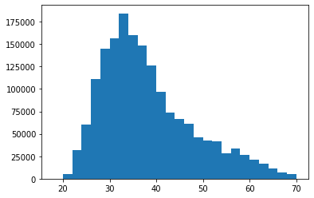

```python
binsize = 2
bins = np.arange(18, df_new['members_age'].max()+binsize, binsize)
plt.hist(data = df_new, x = 'members_age', bins = bins);
```

now looks closer to normal distribution

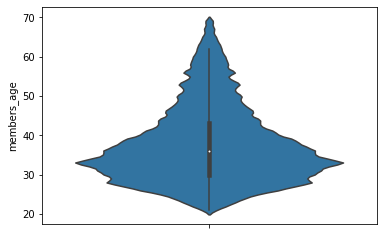

```python
sb.violinplot(data = df_new, y = 'members_age');
```

the above plot shows most of the bikers were around 30 years ols (25-35)

```python
# save cleaned data
df_new.to_csv('clean_data.csv', index=False)
```

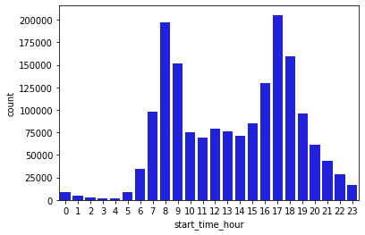

```python
sb.countplot(data = df_new, x = 'start_time_hour', color = 'blue');
```

It shows 8 AM and 5 PM are the most busiest time of the day

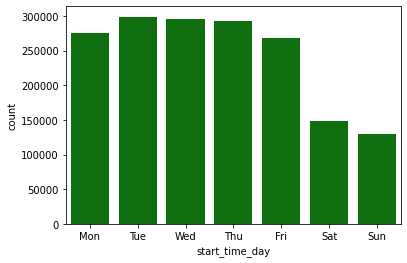

```python
sb.countplot(data = df_new, x = 'start_time_day', color = 'green');
```

Tuesday Wednesday and Thursday have the most bikers however Tuwsday got the most.

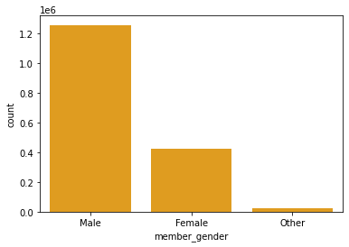

```python
sb.countplot(data = df_new, x = 'member_gender', color = 'orange');
```

Male bikers are 3 times more than female bikers

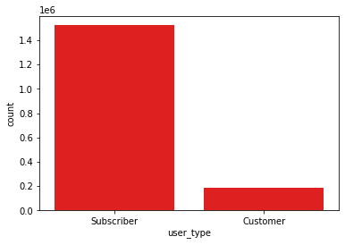

```python
sb.countplot(data = df_new, x = 'user_type', color = 'red');
```

## Bivariate Exploration

```python
samples1 = np.random.choice(df_new['duration_min'], 500, replace = False);
samples2 = np.random.choice(df_new['members_age'], 500, replace= False);
```

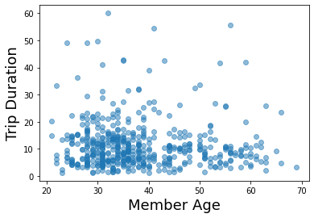

```python
x = samples2
y = samples1
plt.scatter(x, y, alpha=0.5)
plt.ylabel('Trip Duration', fontsize= '18');
plt.xlabel('Member Age', fontsize= '18');
```

There is no specific relationship between members age and trip duration. dense area around 30 shows that there are more members around that age and most of their trip are around 10 mins as we saw before.

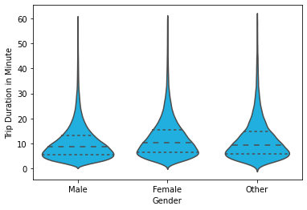

```python
sb.violinplot(data=df_new, x='member_gender', y='duration_min', color='deepskyblue', inner='quartile');
plt.xlabel('Gender');
plt.ylabel('Trip Duration in Minute');
```

Graph does not show much difference between male and female trip duraion, however quartile shows male trips have slightly shorter trip compared to female.

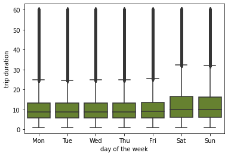

```python
x = df_new['start_time_day']
y = df_new['duration_min']

sb.boxplot(data= df_new, x= x , y= y, color= 'olivedrab')
plt.xlabel('day of the week')
plt.ylabel('trip duration')
```

Trip duration during the weekend is longer than other days of the week.

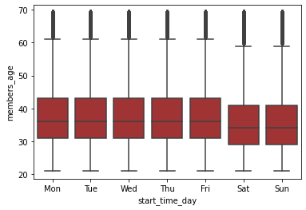

```python
x = 'start_time_day'
y = 'members_age'
sb.boxplot(data= df_new, x= x, y= y, color= 'firebrick');
```

The mean age of the bikers are similar during the week, The mean age of the bikers are similar during the weekend mean age of bikers on Saturday and Sunday are less then the mean age of bikers on the other days of a week.

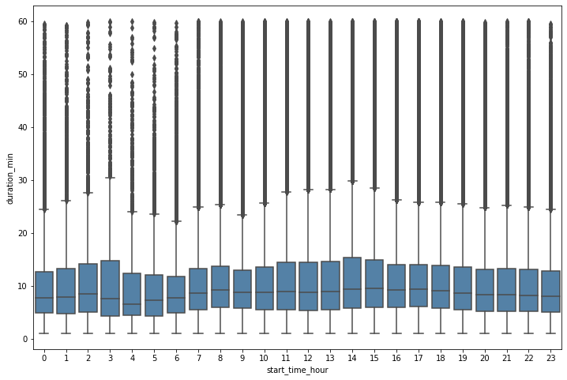

```python
plt.figure(figsize= (12,8))
x = 'start_time_hour'
y = 'duration_min'
sb.boxplot(data= df_new, x= x, y= y, color= 'steelblue')
```

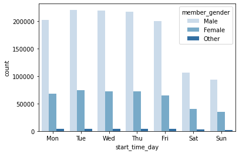

```python
sb.countplot(data= df_new, x='start_time_day', hue= 'member_gender', palette = 'Blues');
```

It shows in general male user are more than felame users (as shown before) and it indicates that the amount of users on Saturday and Sunday are less than the other days of the week which can be concluded that bikes more get used in order to go work during the weekdays.

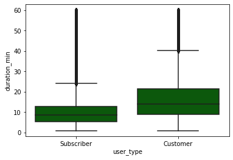

```python
x= 'user_type'
y= 'duration_min'
sb.boxplot(data= df_new, x= x, y= y, color= 'darkgreen')
```

Customer has a wider range of trip duration and the mean duration of subscriber is less than the mean duration of customers.

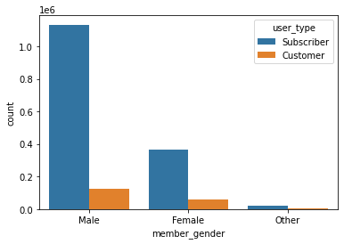

```python
sb.countplot(data = df_new, x = 'member_gender', hue = 'user_type');
```

Male subscriber and male customers are more than female sunscriber and female customers.

## Did you observe any interesting relationships between the other features (not the main feature(s) of interest)?

- In general male user are more than felame users. The amount of users on Saturday and Sunday are less than the other days of the week which can be concluded that bikes more get used in order to go work during the weekdays.
- The mean age of the bikers are similar during the week,
- The mean age of the bikers are similar during the weekend
- mean age of bikers on Saturday and Sunday are less then the mean age of bikers on the other days of a week.
- Male subscriber and male customers are more than female sunscriber and female customers.

## Multivariate Exploration

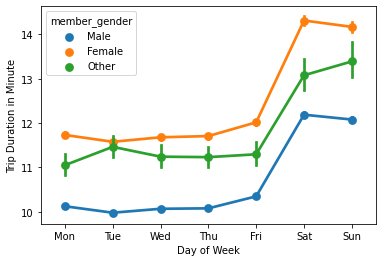

```python
sb.pointplot(data= df_new, x='start_time_day', y='duration_min', hue='member_gender');
plt.xlabel('Day of Week');
plt.ylabel('Trip Duration in Minute');
```

different gender has longer trip during the weekend, female takes longer trip compared to male and others during the whole week. They both show an almost consistent average duration from Monday Friday

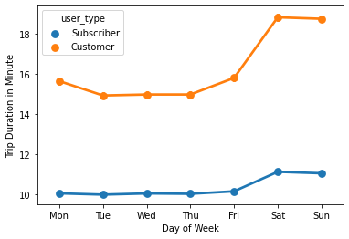

```python
sb.pointplot(data= df_new, x='start_time_day', y='duration_min', hue='user_type');
plt.xlabel('Day of Week');
plt.ylabel('Trip Duration in Minute');
```

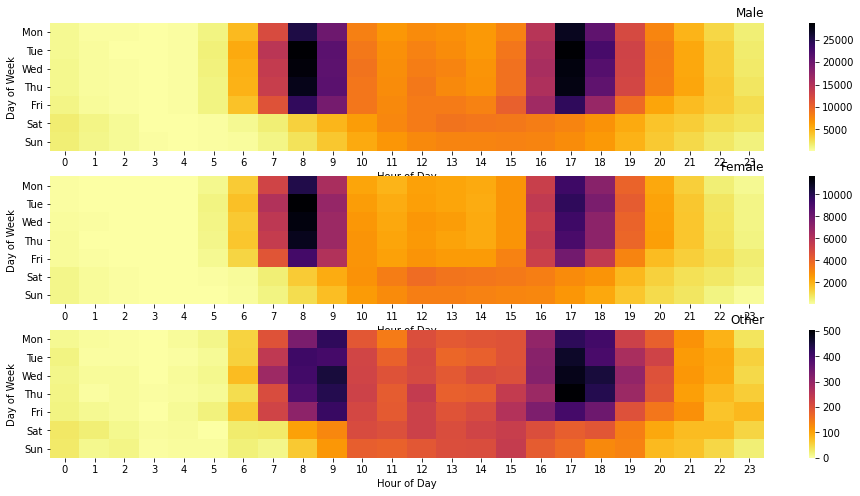

```python
plt.suptitle('Hourly Usage during the week for members gender')
plt.figure(figsize= (16,8));
plt.subplot(3, 1, 1)
customers = df_new.query('member_gender == "Male"')
ct_counts = customers.groupby(['start_time_day', 'start_time_hour']).size()
ct_counts = ct_counts.reset_index(name='count')
ct_counts = ct_counts.pivot(index='start_time_day', columns='start_time_hour', values='count')
sb.heatmap(ct_counts, cmap='inferno_r');
plt.title('Male', loc='right');
plt.xlabel('Hour of Day');
plt.ylabel('Day of Week');

plt.subplot(3, 1, 2)
subscribers = df_new.query('member_gender == "Female"')
st_counts = subscribers.groupby(['start_time_day', 'start_time_hour']).size()
st_counts = st_counts.reset_index(name='count')
st_counts = st_counts.pivot(index='start_time_day', columns='start_time_hour', values='count')
sb.heatmap(st_counts, cmap='inferno_r');
plt.title('Female', loc='right');
plt.xlabel('Hour of Day');
plt.ylabel('Day of Week');

plt.subplot(3, 1, 3)
subscribers = df_new.query('member_gender == "Other"')
st_counts = subscribers.groupby(['start_time_day', 'start_time_hour']).size()
st_counts = st_counts.reset_index(name='count')
st_counts = st_counts.pivot(index='start_time_day', columns='start_time_hour', values='count')
sb.heatmap(st_counts, cmap='inferno_r');
plt.title('Other', loc='right');
plt.xlabel('Hour of Day');
plt.ylabel('Day of Week');
```

The heatmaps shows same habit for different genders. all the gender use bikes mainly during the weekdays Monday to Friday. Most of the bikes for male, female and other gender were used during the early hours in the morning before they start work and between 4 to 6 PM when they finish work. It can be a good way out of traffic during busy time of the day.

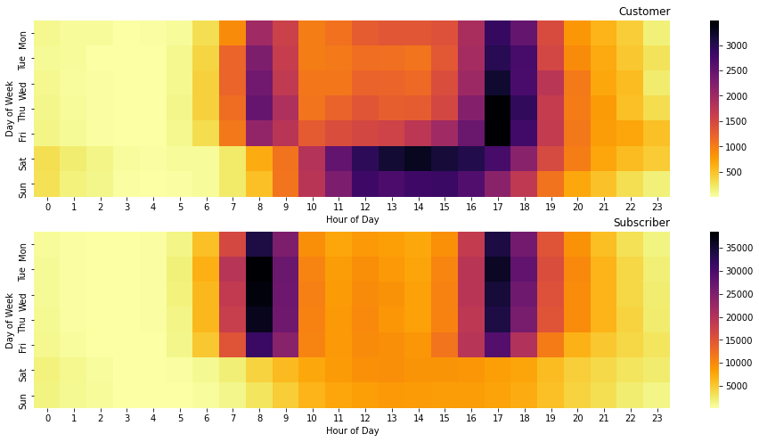

```python
plt.suptitle('Hourly Usage during the week for user type')
plt.figure(figsize= (16,8));
plt.subplot(2, 1, 1)
customers = df_new.query('user_type == "Customer"')
ct_counts = customers.groupby(['start_time_day', 'start_time_hour']).size()
ct_counts = ct_counts.reset_index(name='count')
ct_counts = ct_counts.pivot(index='start_time_day', columns='start_time_hour', values='count')
sb.heatmap(ct_counts, cmap='inferno_r');
plt.title('Customer', loc='right');
plt.xlabel('Hour of Day');
plt.ylabel('Day of Week');

plt.subplot(2, 1, 2)
subscribers = df_new.query('user_type == "Subscriber"')
st_counts = subscribers.groupby(['start_time_day', 'start_time_hour']).size()
st_counts = st_counts.reset_index(name='count')
st_counts = st_counts.pivot(index='start_time_day', columns='start_time_hour', values='count')
sb.heatmap(st_counts, cmap='inferno_r');
plt.title('Subscriber', loc='right');
plt.xlabel('Hour of Day');
plt.ylabel('Day of Week');
```

The heatmaps shows different habbit for customers and subscribers. customers use bikes less during the weekdays and more during the weekend however subscirbers mainly use bike to get to work in the morning and go home from work in the evening.

### Talk about some of the relationships you observed in this part of the investigation. Were there features that strengthened each other in terms of looking at your feature(s) of interest?

The multivariate exploration make some of the observation in previous parts stronger. relationship between multiple variables are plotted in this section and gives a better understanding of the relationship between different parameters. more usage during the rush hours show that bikes mainly used between male and female and others in order to get to work and skip the traffic. The heatmap for hourly usage during weekdays for customers and subscribers show different pattern among two different types of users. Subscribers mainly use bikes to get to work during early hours in the morning and evening after work to skip the traffic however customers also use bikes during the weekend between 10 AM to 6 PM.

### Were there any interesting or surprising interactions between features?

It was not a surprising data however all of the observation together help us to have a better undrestanding of the data and results, usage habbit between male and female are quit similar however the female data was not as much as male data, it would be interesting to see the female habbit if there were more female data.